# Project 04

## Overview

See the project description for instructions. The final output will be this RMarkdown file *knit* into HTML. More detailed instructions are given on the Project 4 page linked to from the course website.

**Project Team**: Jeremy Mednik Jackson McAtee, Brian Schnabel

**Community Area**: Forest Glen

**Crime Type**: Theft

## Project 04

### Description of Community Area

The first plot we used to describe the community area shows the population in each community area in Chicago. It is color coded on a map scale to help show areas of high population in red. We can see from the graph that Forest Glen has a particularly low population relative to other community areas in Chicago. It also borders two communities with low populations.

The second graph we used to describe the demographic of Forest Glen related unemployment to income for each community area. We found a trend line between the two variables which was negatively sloped. This is intuitive with what economics would tell us. The graph shows that Forest Glen is a relatively wealthy area with low unemployment and high income compared to the mean of communities in Chicago.

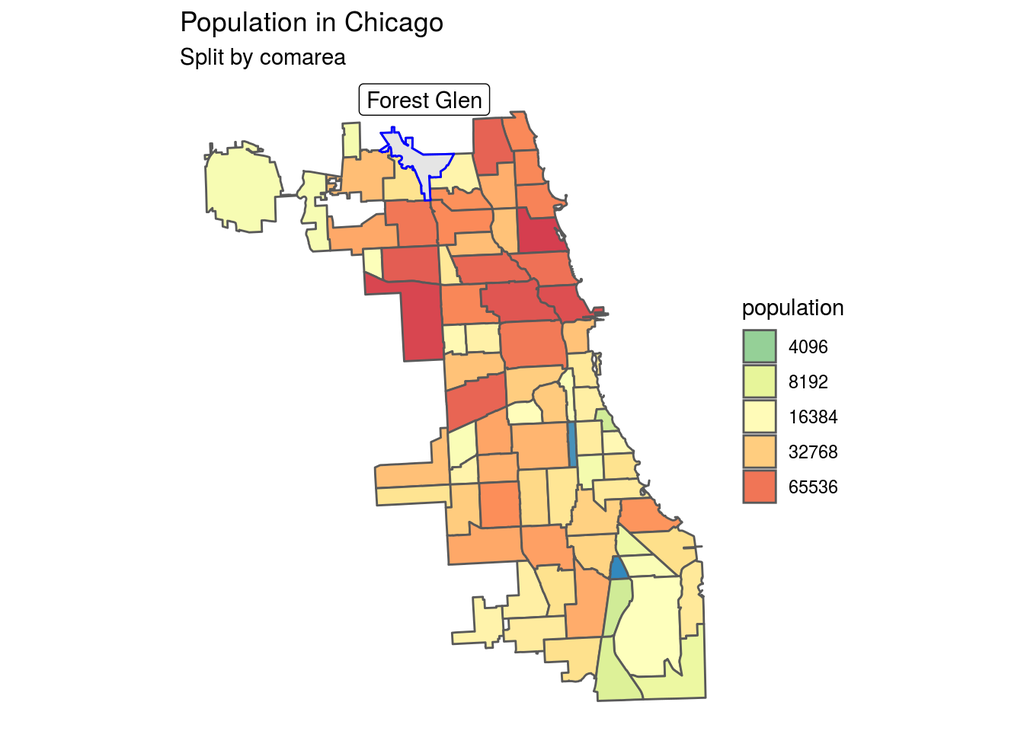

```r
crimes %>%
  group_by(comarea) %>%
  summarize(sm_count()) %>%
  inner_join(comarea, by = "comarea") %>%
  inner_join(socio, by = "comarea") %>%
  st_as_sf() %>%
  st_transform(3436) %>%
  ggplot() +
  geom_sf(aes(fill = population)) +
  scale_fill_distiller(trans = "log2", palette = "Spectral", guide = "legend", n.breaks = 10) +
  theme_void() +
  geom_sf(color = "blue", data = filter(comarea, comarea_name == "Forest Glen")) +
  geom_sf_label(label = "Forest Glen", data = filter(comarea, comarea_name == "Forest Glen"), nudge_y = 15000) +
  labs(title = "Population in Chicago", subtitle = "Split by comarea", color = "Population" )
```

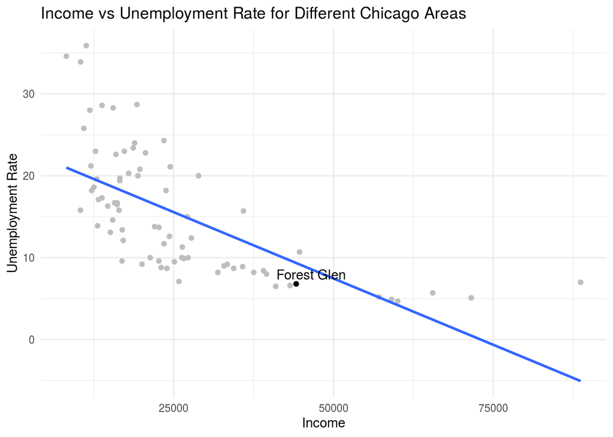

```r
socio %>%
  ggplot(aes(income, unemployed)) +
    geom_point(color = "grey") +
    geom_point(color = "black", data = filter(socio, comarea_name == "Forest Glen")) +
    geom_smooth(method = "lm", se = FALSE) +
    geom_text_repel(aes(label = comarea_name), color = "black", data = filter(socio, comarea_name == "Forest Glen")) +
    labs(title = "Income vs Unemployment Rate for Different Chicago Areas", x = "Income", y = "Unemployment Rate")
```